# 第6回 正則化回帰（似すぎた係数に罰金・強さ α を交差検証で選ぶ）

経済データとプログラミングII

第6回

正則化回帰

似すぎた係数に罰金・強さ α を交差検証で選ぶ

経済データとプログラミングII

第6回 — Topic01

前の回の復習と罰金の考え方

似すぎた 2 つを、両方残せる？

## 第6回の道のり

1

罰金の考え方

実習：写経 1 5 人の Ridge

演習 6-1 A さんの自習の変更

2

今月と先月の暴れ

実習：実行 景気データの準備

実習：写経 2 今月と先月の Ridge

実習：実行 Lasso の実行

3

訓練とテスト

実習：実行 13 列の準備

実習：写経 3 訓練とテストの採点

演習 6-2 くじの番号の変更

4

交差検証で $\alpha$

実習：実行 候補と交差検証

実習：写経 4 選んだ $\alpha$ で採点

実習：実行 Lasso の交差検証

いまココ — 似すぎた 2 つの係数に、罰金を掛ける

## 前の回の振り返り

重回帰の係数は「ほかの説明変数をそろえた差」  
5 人の表にシフト回数 $w$ を足すと、バイト日数 $x$ の係数は $0.0$、$w$ は $-2.5$

[figure not shown]

A さんの自習を 1 時間ずらすだけで、$x$ の係数は $-1.0$ ／ $+1.0$ とひっくり返る  
和はいつも $-2.5$。B〜E は日数と回数が同じ数なので、分け方は A さん 1 人で決まる

## 今月と先月の先行の係数

前の回の景気動向指数。同じ月の一致指数を、今月の先行指数で説明した  
そこへ先月の先行指数を足すと

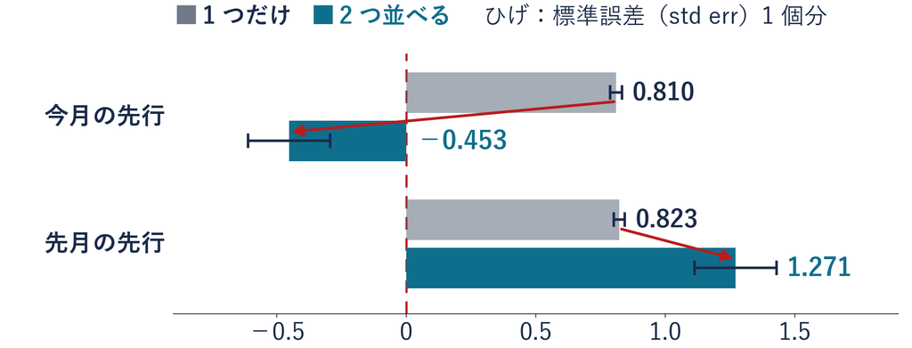

今月の係数は $0.810$ から $-0.453$ へ。**符号まで逆**になった  
ばらつき（`std err`）は $0.023$ から $0.159$ へ約 7 倍。2 つの VIF は $55.2$

## 前の回の対処と残した問い

前の回の対処

Q: 似すぎた 2 つに、前の回はどう対処したか

- **VIF を測る**：似すぎを見つける（5 人 $17.0$・景気 $55.2$）
- **何をそろえて読むかを決める**：係数は「ほかをそろえた差」
- **同じ情報なら 1 つだけ使う**：今月と先月の先行なら、今月

予測するだけなら、あまり困らない。困るのは係数を 1 つずつ読むとき  
でも 1 つに落とすと、もう片方の情報を捨てる（景気なら、今月も先月も見たい）

前の回の最後に「係数の暴れを抑える別の方法は、あとで扱う」と言った  
問い：両方残したまま、暴れだけ抑えられないか

## このトピックで学ぶこと

- **何をやるか**：係数の大きさに罰金を掛ける
- **なぜ**：似すぎた 2 つを両方残すと、  
  少しのデータの違いで分け方がひっくり返る
- **いつ効くか**：似た変数を両方残したいとき  
  （1 つに落とせば済むなら、それでもよい）
- **土台**：前に出てきた二乗誤差の和。最小にする量に 1 項足すだけ

問い：両方残したまま、分け方を落ち着かせられる？

## ◼ 正則化

定義

**正則化**：最小にする量に、係数が大きいことへの**罰金**を足すこと
$$\min\ \text{二乗誤差の和} + \alpha \times \text{罰金}$$

- **心**：和が同じなら、片方に大きく偏った組ほど罰金が高い。だから選ばれにくい
- **罰金の形は 2 つ**：二乗（Ridge）と絶対値（Lasso）。このトピックは二乗の Ridge
- **Ridge の罰金**：係数の二乗の和 $b_1^2 + b_2^2 + \cdots$。切片 $b_0$ には掛けない
- **$\alpha$**：罰金の強さ。$0$ なら罰金なし＝これまでの最小二乗

手順

STEP 1線ごとに、二乗誤差の和を出す

STEP 2罰金 $\alpha \times$ 係数$^2$ を出す

STEP 3足して合計にする

STEP 4合計がいちばん小さい線を選ぶ

## STEP 1〜4 5 人の線に足す罰金

5 人の自習時間 9、10、6、2、3（日数は 1〜5）

[figure not shown]

罰金を足すと、底（合計がいちばん小さい線）は傾き −2 から −1 へ  
罰金は係数を 0 の側へ引っ張る

## 5 人の 2 つの係数の分け方

今度は $x$ と $w$ の 2 つ。和を $-2.5$ にそろえて分け方だけ変え、罰金 $\alpha = 1$ を足す

[figure not shown]

罰金なしの底は偏った $(0, -2.5)$。罰金を足すと、底は半々に近い $(-1.0, -1.5)$ へ  
本当の Ridge は和も少し縮めて $(-0.92, -1.24)$（和 $-2.16$）。合計はさらに小さい

## A さんの自習を 1 時間ずらした Ridge

前の回と同じ実験。A さんの自習が 1 時間多かったら（10）、$x$ の係数は

[figure not shown]

罰金なしは $0.0 \to -1.0$。Ridge は $-0.92 \to -1.19$ で、符号は変わらない  
罰金という条件を足したので、分け方が A さん 1 人に振り回されにくくなった

どちらが本当に自習を減らすかが分かったわけではない

## 写経 1 5 人の 2 つの係数の Ridge

```python
import pandas as pd
from sklearn.linear_model import Ridge
d = pd.DataFrame({"x": [1, 2, 3, 4, 5],
                  "w": [2, 2, 3, 4, 5],
                  "y": [9, 10, 6, 2, 3]})
m = Ridge(alpha=1)
m.fit(d[["x", "w"]], d["y"])
print(m.coef_.round(2), m.intercept_.round(2))
```

| 行 | 部品 | 渡すもの | できるもの |
| --- | --- | --- | --- |
| 1-2 | **道具を呼ぶ** | 表の道具・罰金つきの回帰 `Ridge` |  |
| 3-5 | **5 人の表** | $x$・$w$・$y$ の 3 列 | 表 `d` |
| 6 | **罰金の強さ** | `alpha=1` | 罰金つきの模型 `m` |
| 7 | **当てはめる** `.fit` | 入力の表 d [["x", "w"]] ・答えの列 `d["y"]` | 合計が最小の係数 |
| 8 | **読む** `.coef_`・`.intercept_` | 係数 2 つと切片 | `[-0.92 -1.24] 12.72` |

※ 前の回は式（`y ~ x + w`）で渡した。sklearn は入力の表 X  
（`[[ ]]` で表の形）と答えの列 y を分けて渡す

## コードセルの写経と実行

1. **＋ コード**で空のセルを足す  
   （案内の文の下）
2. 写経 1 の 8 行を上  
   から写す
3. **▶** か **Shift + Enter** で実行  
   （Mac は Shift + return）
4. 係数 2 つと切片を見る

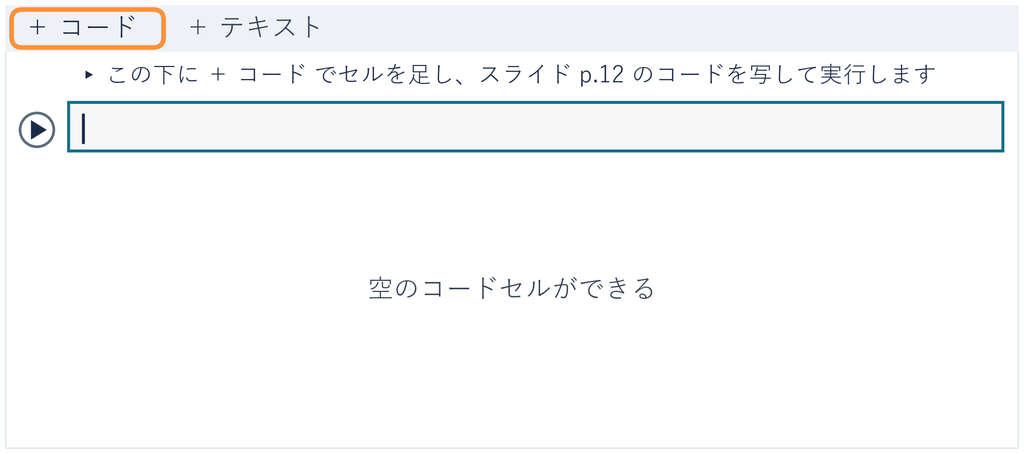

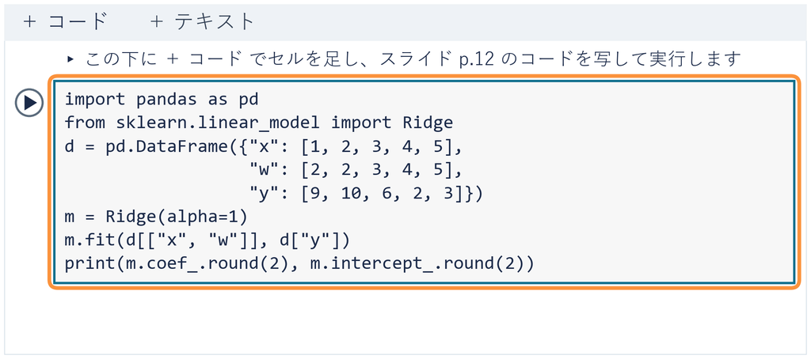

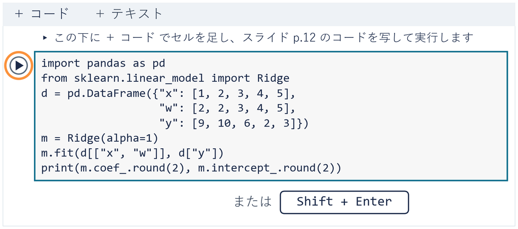

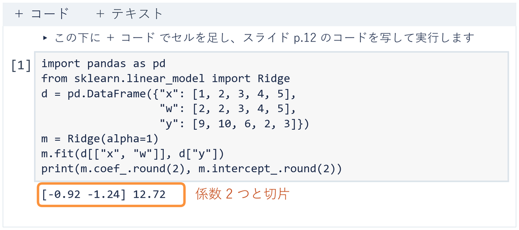

⏸ PAUSE 動画を止めて $2$ 分。`[-0.92 -1.24] 12.72` が出たら再生に戻る

## 演習 6-1 A さんの自習の変更

演習 6-1

A さんの自習を 9 → 8 にすると、Ridge の $x$ の係数は

```python
d = pd.DataFrame({"x": [1, 2, 3, 4, 5],
                  "w": [2, 2, 3, 4, 5],
                  "y": [8, 10, 6, 2, 3]})
```

1. **先に考える**：ⓐ $+$ に変わる ⓑ $-$ のまま
2. **写して変える**：写経 1 の 8 行を新しいセルに写し、`9` を `8` に
3. **終わり**：答え欄に ⓐ か ⓑ と、Ridge の $x$ の係数

⏸ PAUSE 動画を止めて $3$ 分。答えを書いたら再生に戻る

## 演習 6-1 の答え

答えは **ⓑ $-$ のまま**。Ridge の $x$ の係数は $-0.64$（出力 `[-0.64 -1.37] 12.1`）

| A さんの自習 | 罰金なしの $x$ | Ridge の $x$ |
| --- | --- | --- |
| 10 時間 | $-1.0$ | $-1.19$ |
| 9 時間（いつもの表） | $0.0$ | $-0.92$ |
| 8 時間 | $+1.0$ | $-0.64$ |

罰金なしは 1 時間で符号が変わる。  
Ridge は $-1.19$ から $-0.64$ の間で動くだけ

## まとめ

- 似すぎた 2 つを両方入れると、  
  罰金なしでは A さん 1 人の 1 時間で係数の符号が変わる
- **正則化**：二乗誤差の和に $\alpha \times$ 罰金を足して最小にする。  
  Ridge の罰金は係数の二乗の和
- 罰金を足すと、  
  偏った分け方 $(0, -2.5)$ より半々に近い分け方が選ばれる  
  （Ridge は $-0.92$・$-1.24$）
- 落ち着いたのは罰金という条件のおかげ。  
  どちらが本当に効くかが分かったわけではない

罰金を足すと、似すぎた 2 つの分け方が落ち着いた  
残った問い：罰金の形は二乗だけか。  
本物の今月と先月でも効くか。これを次のトピックで見る

経済データとプログラミングII

第6回 — Topic02

Ridge と Lasso で暴れを抑える

今月と先月の先行に罰金を掛けると？

## 第6回の道のり

1

罰金の考え方

実習：写経 1 5 人の Ridge

演習 6-1 A さんの自習の変更

2

今月と先月の暴れ

実習：実行 景気データの準備

実習：写経 2 今月と先月の Ridge

実習：実行 Lasso の実行

3

訓練とテスト

実習：実行 13 列の準備

実習：写経 3 訓練とテストの採点

演習 6-2 くじの番号の変更

4

交差検証で $\alpha$

実習：実行 候補と交差検証

実習：写経 4 選んだ $\alpha$ で採点

実習：実行 Lasso の交差検証

いまココ — 今月と先月の暴れを、2 つの罰金で抑える

## このトピックで学ぶこと

- **いまの道具で**：5 人では、Ridge で分け方が落ち着いた
- **足りない所**：Ridge は係数をちょうど 0 にしないので、  
  使わなくてよい変数を言えない。本物の景気のデータで効くかもまだ
- **何をやるか**：前半は 5 人で、絶対値の罰金（Lasso）。  
  後半は今月と先月の先行に、Ridge と Lasso を掛ける
- **いつ効くか**：似た変数を両方残したいときは Ridge、  
  使う変数をしぼりたいときは Lasso

問い：罰金の形を替えると？ 本物の今月と先月でも、暴れは収まる？

## ◼ Lasso

定義

**Lasso**：罰金を、係数の**絶対値**の和にした正則化
$$\min\ \text{二乗誤差の和} + \alpha \times (|b_1| + |b_2| + \cdots)$$

- **絶対値**：マイナスを外した大きさ。$|-2| = 2$
- **切片 $b_0$**：Ridge と同じく、罰金を掛けない
- **手順**：前のトピックの STEP 1〜4 と同じ。STEP 2 の罰金だけ $\alpha \times |\text{係数}|$ に替える
- **心**：小さい係数ほど、二乗より重い罰金（$0.4^2 = 0.16$、$|0.4| = 0.4$）。  
  だから小さい係数は 0 にしたほうが得

Ridge は二乗、Lasso は絶対値。違うのは罰金の形だけ

## 5 人の線と Lasso の罰金（STEP 1〜4）

5 人の自習時間 9、10、6、2、3（日数は 1〜5）・平均の点は (3, 6)

[figure not shown]

傾き $-0.5$ の線 $7.5 - 0.5x$：残差は $2,\ 3.5,\ 0,\ -3.5,\ -2$  
→ 二乗の和 $4 + 12.25 + 0 + 12.25 + 4 = 32.5$

$\alpha = 20$ で底は −1。前のトピックの Ridge（$\alpha = 10$）と同じ底になった

## 罰金の強さと底の傾きの比較

Ridge の底の傾き：$-20 \div (10 + \alpha)$ $-20$ と $10$ は 5 人の表で決まる数  
動くのは分母の $\alpha$ だけ。0 に近づくが、0 ちょうどにはならない

[figure not shown]

Lasso は $\alpha = 40$ で底が 0 に止まり、強くしても 0 のまま  
$\alpha = 40$ の合計は、傾きを 0 からどちらに動かしても増える

## Ridge の円と Lasso のひし形

係数 2 本だけの模式図。横も縦も係数

[figure not shown]

点 1 つ＝係数の組 1 つ（黒い点が罰金なしの答え） 輪＝二乗誤差の和が同じ組  
円：$b_1^2 + b_2^2 \le 1$ ひし形：$|b_1| + |b_2| \le 1$（係数の大きさの合計の上限）

★＝輪を広げて最初に触れる点＝選ぶ組  
上限を $\alpha$ に合わせて選べば、「二乗誤差の和＋罰金を最小に」と同じ答え

## よくある失敗 0 になった変数の読み方

5 人の $x$（バイト日数）と $w$（シフト回数）に Lasso（コードの $\alpha = 0.5$）

| A さんの自習 | $x$ の係数 | $w$ の係数 |
| --- | --- | --- |
| 9 時間（いつもの表） | $-0.75$ | $-1.25$ |
| 10 時間 | $-1.75$ | $-0.25$ |
| 8 時間 | **$0$** | $-1.96$ |

✕ 0 になった変数は、関係が無い

8 時間の表で $x$ が 0。  
だからバイト日数は関係が無い

○ 1 時間の違いで、  
バイト日数が 0 になるかが変わる

9・10 時間の表では $x$ は残る

0 は「この強さ・このデータでは使わなかった」。  
関係が無いことの証明ではない

## 景気動向指数を読む準備のセル

```python
import pandas as pd
BASE = "ここに manaba の URL を貼る"
ci = pd.read_csv(BASE + "ci_composite.csv")
ci = ci.dropna()
ci["lead_prev"] = ci["ci_leading"].shift(1)
ci = ci.dropna()
print(ci.shape)
```

| URL の形の例：`BASE` に貼る（**最後の / まで**） | ファイル名（3 行目がつなぐ） |
| --- | --- |
| `https://○○○/data/` | `ci_composite.csv` |

| 行 | 書き方 | 意味 |
| --- | --- | --- |
| 1-2 | 道具と `BASE` | manaba に載せた URL の**最後の / まで**を引用符の中に貼る |
| 3-4 | 読む・落とす | 景気動向指数の表 `ci`。空欄のある月を落として 497 か月 |
| 5-6 | 先月の列 `shift(1)` | 今月の先行を 1 か月下へずらす（最初の月は落とす） |
| 7 | 大きさ | `(496, 8)`：496 か月・8 列 |

⏸ PAUSE **写経せず実行するセル**。動画を止めて $1$ 分。`(496, 8)` が出たら再生に戻る

## ★ 罰金の強さと 2 つの係数

横：罰金の強さ $\alpha$（右ほど強い） 縦：496 か月の Ridge で出した今月と先月の係数

[figure not shown]

| $\alpha$ | 今月 | 先月 | 和 | 係数の二乗の和 | $R^2$ |
| --- | --- | --- | --- | --- | --- |
| $0$（罰金なし） | $-0.453$ | $1.271$ | $0.819$ | $1.821$ | $0.7524$ |
| $1{,}000$ | $0.135$ | $0.676$ | $0.811$ | $0.475$ | $0.7453$ |
| $100{,}000$ | $0.201$ | $0.209$ | $0.410$ | $0.084$ | $0.5531$ |

今月は 0 へ縮むとは限らず上がる。減り続けるのは係数の二乗の和  
強すぎると $R^2$ まで失う（$0.5531$）。2 列は目盛りがほぼ同じなので、そのまま使う

## デモ：係数の実験室（罰金つき）

数の話

一致指数を、今月と先月の先行で説明する Ridge。  
罰金の強さ α だけを動かし、月の選び直しはどの α でも同じ

- **何を見るか**：前の回の多重共線性のトピックで動かした実験室  
  （今月と先月の先行を並べると、今月の係数の点が横に長く散らばった）。  
  罰金を強くすると、今月の係数の散らばりはどうなるか
- **図の意味**：上は係数の棒と点、下は 2 つの係数の点、右は α と読み出し
- **操作**：α のつまみ（0〜100,000 の 8 段）とタブ 3 つ（α 0・1,000・10,000）  
  ／引き直す 1・10・100 回（1000 回で止まる）／戻す

ミッション α 1,000 で、今月の点の広がりは（同じ／狭くなる／広くなる）？

※ 次のスライドへ進むときは、デモの枠の外を一度クリックしてから ← → キーを押す

[interactive chart not shown]

## ★ 引き直しで見る今月の係数

前の回と同じ引き直し 1000 回（月の選び方も同じ）。違うのは罰金だけ

[figure not shown]

今月の散らばりは $0.2155 \to 0.0592$（$\alpha = 10{,}000$ なら $0.0128$）。＋ になった回は 3 → 990  
VIF は 55.2 のまま。似すぎは列の性質で、変わったのは係数の散らばり

罰金という条件を足して、分け方を安定させた。  
今月の本当の効き目が分かったわけではない

※ 罰金つきの係数に、前の回の `std err` や $t$ 値は使わない。散らばりは引き直しで測った

## Q&A 定理 1 と罰金

Q 前の回の**定理 1**「変数を足しても、$R^2$ は下がらない」は、  
罰金があっても成り立つ？

**いいえ。$R^2$ は下がることもある**  
定理 1 のわけ：足した変数の係数を 0 にすれば、元の線が作れる  
だから、線を選ぶ基準（罰金なしでは二乗誤差の和）は悪くならない

Q では、罰金つきで悪くならないのは？

同じ $\alpha$ なら、**合計（二乗誤差の和＋罰金）の最小**。  
線を選ぶ基準がこの合計だから  
合計を下げるために、係数を分けて罰金を安くする代わりに  
二乗誤差の和が増えることがある。そのとき $R^2$ は下がる  
今回（$\alpha = 1{,}000$）は上がった：$0.7198 \to 0.7453$

## 写経 2 今月と先月の先行の Ridge

```python
X2 = ci[["ci_leading", "lead_prev"]]
y2 = ci["ci_coincident"]
m = Ridge(alpha=1000)
m.fit(X2, y2)
print(m.coef_.round(3), round(m.score(X2, y2), 3))
```

| 行 | 部品 | 渡すもの | できるもの |
| --- | --- | --- | --- |
| 1-2 | **入力と答え** | 今月と先月の先行の 2 列・一致の列 | 表 `X2`・列 `y2` |
| 3 | **罰金の強さ** | `alpha=1000` | 罰金つきの模型 `m` |
| 4 | **当てはめる** `.fit` | `X2`・`y2` | 合計が最小の係数 |
| 5 | **読む** `.coef_`・`.score` | 係数 2 つ（3 桁）・$R^2$ | `[0.135 0.676] 0.745` |

※ `Ridge` は写経 1 で呼んだ道具、`ci` は準備のセルで作った表。`.score` は $R^2$ を返す

⏸ PAUSE 動画を止めて $2$ 分。`[0.135 0.676] 0.745` が出たら再生に戻る

## Ridge と Lasso の 2 つの係数

同じ 496 か月で、罰金なし・Ridge・Lasso の係数を並べる

[figure not shown]

Lasso は今月を 0 にして、先月 0.818 だけを残す（$R^2$ 0.7483）  
前の回の対処は「同じ情報なら今月を使う」。  
当てはまりで Lasso に決めさせると、先月が残る

※ Lasso のコードの $\alpha$ は、二乗誤差の和を 2 × 件数（496 か月なら 992）  
で割る目盛り。Ridge の 1,000 とは比べない

## Ridge から Lasso への置き換え

```python
from sklearn.linear_model import Lasso
m = Lasso(alpha=0.5)
m.fit(X2, y2)
print(m.coef_.round(3), round(m.score(X2, y2), 3))
```

| 行 | 部品 | 写経 2 と違う所 | できるもの |
| --- | --- | --- | --- |
| 1 | **道具を呼ぶ** | `Lasso` |  |
| 2 | **名前と強さ** | `Ridge` → `Lasso`・`1000` → `0.5` の **2 か所** | 模型 `m` |
| 3-4 | **当てはめて読む** | 同じ | `[-0. 0.818] 0.748` |

**写経せず、そのまま実行するセル**（ノートの実行のセル）  
※ 係数が `-0.` と出ても 0 と同じ

⏸ PAUSE 動画を止めて $1$ 分。`[-0. 0.818] 0.748` が出たら再生に戻る

## まとめ

- **Lasso**：罰金を係数の絶対値の和にした正則化。  
  5 人では $\alpha = 40$ で底が 0 に止まる（Ridge は近づくだけ）
- ひし形は角で輪に触れることがあり、そのとき係数がちょうど 0
- 今月と先月の先行に Ridge（$\alpha = 1{,}000$）：今月 $-0.453 \to 0.135$。  
  和はほぼ一定・引き直しの散らばり $0.2155 \to 0.0592$
- 落ち着いたのは罰金という条件のおかげ。VIF は 55.2 のまま。  
  本当の効き目が分かったわけではない
- Lasso（コードの $\alpha = 0.5$）は今月を 0 にした。  
  0 は「この強さでは使わなかった」

罰金で、今月と先月の分け方が落ち着いた。Lasso は片方を 0 にした  
残った問い：罰金の強さは、どれにすればよいか。  
手元の $R^2$ で決めてよいか。これを次のトピックで見る

経済データとプログラミングII

第6回 — Topic03

訓練とテスト

罰金の強さは、手元の R² で決めていい？

## 第6回の道のり

1

罰金の考え方

実習：写経 1 5 人の Ridge

演習 6-1 A さんの自習の変更

2

今月と先月の暴れ

実習：実行 景気データの準備

実習：写経 2 今月と先月の Ridge

実習：実行 Lasso の実行

3

訓練とテスト

実習：実行 13 列の準備

実習：写経 3 訓練とテストの採点

演習 6-2 くじの番号の変更

4

交差検証で $\alpha$

実習：実行 候補と交差検証

実習：写経 4 選んだ $\alpha$ で採点

実習：実行 Lasso の交差検証

いまココ — 罰金の強さを、見ていない月で測る

## 罰金の強さと手元の決定係数

前のトピックの今月と先月の先行（496 か月）で、$\alpha$ ごとに  
係数のばらつきと、学ばせた月への当てはまり（手元の $R^2$）を並べる

[figure not shown]

同じ変数のまま強めると、手元の $R^2$ は必ず下がる  
罰金なしの係数が、二乗誤差の和のいちばん小さい組だから

ばらつきだけ見れば強いほどよく、手元の $R^2$ だけ見ればいつも罰金なし  
ここからは、学ばせていないデータへの当たりで強さを選ぶ

## このトピックで学ぶこと

- **いまの道具で**：罰金を強めると、係数のばらつきは小さくなる
- **足りない所**：手元の $R^2$ は罰金なしがいちばん高い  
  ので、強さを決められない
- **何をやるか**：学ばせていないデータで当たりを測る。  
  前半は 5 人で 1 人を隠す。後半は景気の 485 か月を、  
  学ばせる月と採点だけの月に分ける
- **いつ必須か**：設定のつまみ（罰金の強さ $\alpha$ など）  
  があるモデルの当たりを言うとき

問い：見ていないデータへの当たりは、どう測る？

## ◼ 隠して確かめる手順

手元の点で測る $R^2$ は、見ていない点への当たりを言わない。だから 1 点を隠して試す

手順

STEP 1隠す 1 点を決める

STEP 2残りの点で学ぶ（係数を求める）

STEP 3残りの点への当てはまり $R^2$ を読む

STEP 4隠した点を予測し、実際と比べる

次のページで、いつもの 5 人の表から E さんを隠す

## 隠した E さんの予測

STEP 1・2：E さんを隠し、A〜D の 4 人で $x$ と $w$ の係数を求める

| いつもの 5 人 | A | B | C | D | E（隠す） |
| --- | --- | --- | --- | --- | --- |
| バイト日数 $x$ | 1 | 2 | 3 | 4 | 5 |
| シフト回数 $w$ | **2** | 2 | 3 | 4 | 5 |
| 自習時間 $y$ | 9 | 10 | 6 | 2 | 3 |

| A〜D で学んだ | $x$ の係数 | $w$ の係数 | STEP 3 4 人の $R^2$ |
| --- | --- | --- | --- |
| 罰金なし | $+1.0$ | $-5.0$ | $1.00$ |
| Ridge $\alpha = 2$ | $-1.12$ | $-1.33$ | $0.87$ |

[figure not shown]

罰金なしは 4 人にぴったり。でも A さん 1 人で決まった極端な分け方  
罰金を足すと、4 人への当てはまりは 0.87 に下がり、E さんとの差は縮んだ

※ 2 つを並べたのは仕組みを見るため。$\alpha$ を E さんで決めるのではない（決め方は最後のトピック）

## ◼ 訓練データとテストデータ

E さんを隠したのは、学ばせていない相手への当たりを確かめるため

定義

**訓練データ**：学ばせるのに使う分（A〜D の 4 人）

**テストデータ**：最後まで触らずに、採点だけに使う分（E さん）

- **決まり**：テストは、学ばせるのにも、設定を選ぶのにも使わない
- **いまは**：仕組みを見るため、同じテストで比べる。  
  決まりを守る選び方は最後のトピックで

手順

係数訓練で求める

設定 $\alpha$訓練の中で選ぶ（最後のトピック）

採点最後にテストで 1 回だけ採点

## 13 列で説明する一致指数

今度は景気動向指数で、同じ手順を。13 列で同じ月の一致指数を説明する

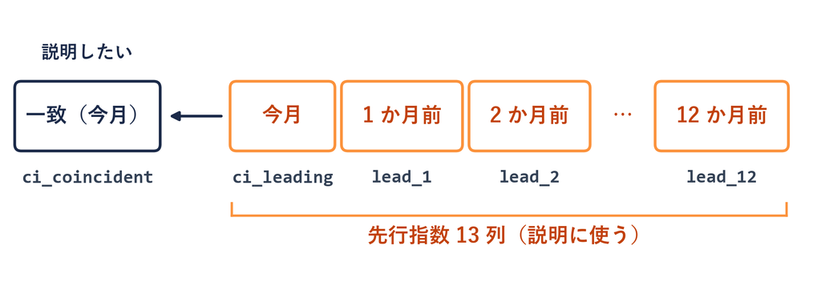

- **一致指数**：景気と同時に動く（例：鉱工業の生産指数）。いまの景気を映す
- **先行指数**：景気より数か月先に動く（例：新規求人数）。$k$ か月前の値が列 `lead_k`

どの列も隣の月とほぼ同じ動き。13 列の VIF は 64〜193  
前のトピックの似すぎ（2 列）が、13 列に広がった

## 13 列を作る準備のセル

```python
ci = pd.read_csv(BASE + "ci_composite.csv").dropna()
cols = ["ci_leading"]
for k in range(1, 13):
    ci[f"lead_{k}"] = ci["ci_leading"].shift(k)
    cols.append(f"lead_{k}")
ci = ci.dropna()
X, y = ci[cols], ci["ci_coincident"]
print(X.shape)
```

| 行 | 書き方 | 意味 |
| --- | --- | --- |
| 1 | 読み直す | 前のトピックと同じ表を、 先月の列を足す前から読み直す（497 か月） |
| 2-5 | 13 列を作る | `shift(k)` で `k`（1〜12）か月下へずらし、 名前 `f"lead_{k}"` で足す |
| 6-7 | 落として分ける | 欠けた 12 か月を落とし、入力 `X` と答え `y` に |
| 8 | 大きさ | `(485, 13)`：485 か月・13 列 |

⏸ PAUSE **写経せず実行するセル**（ノートのトピック 3 の準備）。  
動画を止めて $1$ 分。`(485, 13)` が出たら再生に戻る

## 訓練とテストの無作為分割

E さんを隠したのと同じことを 485 か月で  
4 分の 1 の 122 か月をくじでテストにして、残りの 363 か月で学ぶ

[figure not shown]

月を混ぜてくじで分けた。これは隠した月への当たり  
過去の月だけで学んで、先の月を当てる評価とは別

## ◼ 標準化

**心**：罰金は係数の大きさを見る  
列の散らばりが違うと、同じ働きでも係数の大きさが変わり、罰金が不公平

定義

**標準化**：列ごとに $z = (\text{値} - \text{平均}) \div \text{標準偏差}$ に直すこと  
ことばでは：その値が、平均から標準偏差何個ぶん離れているか

決まり

平均と標準偏差は訓練だけで決め、テストはその数で引いて割る  
（最後のトピックの分け方でも、学ぶ側ごとに決める）

- **なぜ訓練だけ**：テストの月の平均を混ぜると、見ていないはずの月を少し見たのと同じ
- **道具**：`make_pipeline(StandardScaler(), …)` がこの決まりを守る（写経 3）
- **今回の 13 列**：同じ指数なので、訓練の標準偏差は 9.64〜10.32（近いが同じではない）
- **注**：標準化すると $\alpha$ の目盛りも変わる。前のトピックの 1,000 とは比べない

## ★ 訓練とテストの決定係数

13 列を標準化して、罰金なし（重回帰）と Ridge  
（$\alpha = 1$・$10$）を訓練の 363 か月で学ばせる

[figure not shown]

手元（訓練）では下がり、見ていない月（テスト）では上がった（この範囲では）  
$\alpha = 10$ は仮に置いた値。どこまで強めるかは、まだ決めていない

## 写経 3 13 列の訓練とテスト

```python
from sklearn.model_selection import train_test_split
from sklearn.linear_model import LinearRegression
from sklearn.preprocessing import StandardScaler
from sklearn.pipeline import make_pipeline
Xtr, Xte, ytr, yte = train_test_split(X, y, test_size=0.25,
                                      random_state=42)
for m in [LinearRegression(), Ridge(alpha=10)]:
    p = make_pipeline(StandardScaler(), m).fit(Xtr, ytr)
    print(round(p.score(Xtr, ytr), 3), round(p.score(Xte, yte), 3))
```

| 行 | 部品 | 渡すもの | できるもの |
| --- | --- | --- | --- |
| 1-4 | **道具を呼ぶ** | 分ける・回帰・標準化・つなぐ |  |
| 5-6 | **分ける** | 4 分の 1 をテスト・くじの番号 42 | `Xtr` `Xte` `ytr` `yte` |
| 7 | **模型を順に** | 罰金なしと `Ridge(alpha=10)` | `m` |
| 8 | **標準化 → 回帰で学ぶ** `.fit` | 訓練の `Xtr`・`ytr` だけ | 平均・標準偏差と係数 `p` |
| 9 | **2 回採点** `.score` | 訓練とテスト | `0.779 0.681`・`0.776 0.697` |

※ `Ridge` は写経 1 の道具。テストも訓練の平均・標準偏差で引いて割る

⏸ PAUSE 動画を止めて $2$ 分。2 行出たら再生に戻る

## 演習 6-2 くじの番号の変更

演習 6-2

くじの番号を 0 にすると、テストの $R^2$ は

```python
Xtr, Xte, ytr, yte = train_test_split(X, y, test_size=0.25,
                                      random_state=42)
```

1. **先に考える**：ⓐ 同じ ⓑ 変わる
2. **写して変える**：**＋ コード** で写経 3 の 9 行ぜんぶを新しいセルに  
   写し、6 行目の `42` を `0` に（1 か所）
3. **終わり**：答え欄に ⓐ か ⓑ と、2 つのテストの $R^2$  
   書いたら、ノートの「くじを 42 に戻すセル」を実行

⏸ PAUSE 動画を止めて $3$ 分。答えを書いたら再生に戻る

## 演習 6-2 の答え

答えは **ⓑ 変わる**。出力は `0.767 0.713` と `0.763 0.744`

| テストの $R^2$ | くじ 42 | くじ 0 |
| --- | --- | --- |
| 罰金なし（重回帰） | 0.681 | 0.713 |
| Ridge $\alpha = 10$ | 0.697 | 0.744 |

分け方を変えただけで点数が動く。1 回の点数には、分け方の運が混ざる

良く出る番号を探して選ぶのは、  
答えを見てから問題を選ぶのと同じ（反則）

## まとめ

- 同じ変数で罰金を強めると、  
  係数のばらつきは減るが手元の $R^2$ は必ず下がる
- **訓練データ**で学び、**テストデータ**は採点だけに使う
- 5 人の罰金なしは、隠した E さんを $-2.0$ 時間と予測（Ridge は 0.95）
- **標準化**：平均と標準偏差は訓練だけで決める
- くじの番号を変えると、テストの点数も動く

罰金の強さは手元の $R^2$ では決められず、見ていない月で測る  
残った問い：テストを使わずに、$\alpha$ をどう選ぶか。次のトピックで見る

経済データとプログラミングII

第6回 — Topic04

交差検証で α を選ぶ

罰金の強さ α はどう決める？

## 第6回の道のり

1

罰金の考え方

実習：写経 1 5 人の Ridge

演習 6-1 A さんの自習の変更

2

今月と先月の暴れ

実習：実行 景気データの準備

実習：写経 2 今月と先月の Ridge

実習：実行 Lasso の実行

3

訓練とテスト

実習：実行 13 列の準備

実習：写経 3 訓練とテストの採点

演習 6-2 くじの番号の変更

4

交差検証で $\alpha$

実習：実行 候補と交差検証

実習：写経 4 選んだ $\alpha$ で採点

実習：実行 Lasso の交差検証

いまココ — 罰金の強さを、訓練の中だけで選ぶ

## よくある失敗 テストによる $\alpha$ の選択

✕ テストが最良のαを採用

候補をぜんぶ試し  
テストがいちばん良い $\alpha$ を選ぶ

テストを設定選びに使っている

分け方で点数は動いた  
25 個から最良を採ると  
運で良く出た分まで採る

○ αは訓練の中で選ぶ

検証用を作る  
CV の誤差で選ぶ  
テストは最後に 1 回

選び方は、このあと

演習 6-2：くじを 42 → 0 にしただけで、Ridge のテストの $R^2$ は 0.697 → 0.744

テストは最後の採点だけ。前のトピックの決まりは、選ぶときにも効く

## このトピックで学ぶこと

- **いまの道具で**：訓練とテストに分け、見ていない月で当たりを測れた
- **足りない所**：テストで $\alpha$ を選ぶと、テストが最後の採点に使えなくなる
- **何をやるか**：訓練の中に小さなテストを作り、交代で測る。  
  前半は 5 人で 1 人ずつ。後半は訓練の 363 か月を 5 つに分ける
- **いつ使うか**：罰金の強さ $\alpha$ のような設定を、データで決めたいとき

問い：テストを使わずに、$\alpha$ をどう選ぶ？

## ◼ 検証用と交差検証

**心**：訓練の中に小さなテストを作り、交代で測って運をならす。テストは最後まで取っておく

定義

**検証用**：設定（罰金の強さ $\alpha$ など）を選ぶために  
訓練の中から外して、当たりを試すデータ

**交差検証（$K$ 分割）**：訓練を $K$ 個に分け、交代で 1 つを検証用にして  
$K$ 回学んで測ること

**CV の誤差**：検証用での残差の二乗の平均を、$K$ 回ぶん平均した数  
小さいほど当たる（CV は交差検証の英語の頭文字）

手順

係数訓練で求める

設定 $\alpha$訓練の中で、CV の誤差で選ぶ

採点最後にテストで 1 回だけ採点

## ◼ 交差検証の手順

手順

STEP 1$\alpha$ の候補を並べる

STEP 2各候補で、交代で検証用を変えて $K$ 回学んで測り  
残差の二乗を平均する（CV の誤差）

STEP 3CV の誤差がいちばん小さい候補を選ぶ

STEP 4選んだ候補で訓練全体に学ばせ  
テストを 1 回だけ採点する

13 列では標準化をする。5 人の例では使わない  
標準化の平均と標準偏差は、各回の学ぶ側だけで決める（前のトピックの決まりを守る）

次のページから、5 人で STEP 1〜3。候補は $\alpha = 1$・$2$・$5$・$10$

## 1 人ずつ交代する検証用（STEP 2）

5 人（$x$, $w$, $y$）：A(1, 2, 9)・B(2, 2, 10)・C(3, 3, 6)・D(4, 4, 2)・E(5, 5, 3)  
1 人を検証用に隠し、残りの 4 人で学んで、隠した人を当てる

[figure not shown]

A さんを隠すと、残る B〜E は $x = w$。罰金なしでは 2 つの係数が決まらない

表の数は小数第 2 位に丸めた値。5 回目（E さん）は前のトピックの E さんと同じ数

## STEP 2・3 平均の比較と選択

**今回は** 5 回の残差の二乗を足して 5 で割る（CV の誤差）

$\alpha = 1$

$(0.63 + 7.17 + 0.10 + 8.77 + 8.00) \div 5$

$\approx 4.93$

$\alpha = 1$ の列

$\alpha = 2$

$(0.17 + 7.77 + 0.07 + 9.49 + 4.19) \div 5$

$\approx 4.34$

$\alpha = 2$ の列

$\alpha = 5$

$(0.17 + 9.76 + 0.04 + 11.38 + 0.38) \div 5$

$\approx 4.35$

$\alpha = 5$ の列

$\alpha = 10$

$(1.56 + 12.35 + 0.03 + 13.73 + 0.41) \div 5$

$\approx 5.62$

$\alpha = 10$ の列

平均がいちばん小さいのは $\alpha = 2$（4.34）。STEP 3 で $\alpha = 2$ を選ぶ

罰金なしは 1 回目が決まらないので、平均が出せない。平均は丸める前の値から出した  
5 人しかいないので、テストを別に取らず全員で交代させた（仕組みを見るため）

## ★ CV 曲線による $\alpha$ の選択

今度は景気動向指数の 13 列で、同じ手順を  
訓練の 363 か月を 5 つ（73・73・73・72・72 か月）に分け、候補 $\alpha$ は 25 個

[figure not shown]

CV の誤差は 24.01（ほぼ罰金なし）→ 21.05（谷）→ 25.91（$\alpha = 1{,}000$）  
谷の $\alpha \approx 56$ を選ぶ。月を混ぜて分けたので、これも隠した月への当たり

## 候補と交差検証のコード

```python
import numpy as np
from sklearn.model_selection import KFold, cross_val_score
alphas = np.logspace(-3, 3, 25)
kf = KFold(5, shuffle=True, random_state=42)
cv = []
for a in alphas:
    m = make_pipeline(StandardScaler(), Ridge(alpha=a))
    s = cross_val_score(m, Xtr, ytr, cv=kf,
                        scoring="neg_mean_squared_error")
    cv.append(-s.mean())
best = alphas[np.argmin(cv)]
print(best)
```

| 行 | 部品 | 意味 |
| --- | --- | --- |
| 1-2 | **道具を呼ぶ** | 数の道具 `np`・分け方 `KFold`・測る `cross_val_score` |
| 3 | **STEP 1 候補** | 10 の −3 乗（0.001）から 3 乗（1000）まで、同じ倍率で 25 個 → `alphas` |
| 4 | **分け方** | 訓練を混ぜて 5 つに分ける（5 はよく使う目安）。42 は混ぜるくじの番号 |
| 5-7 | **模型を作る** | `cv` は点数を入れる箱。候補を 1 つずつ `a` に（標準化 → Ridge） |
| 8-10 | **STEP 2 5 回測る** | 5 回分の点数 `s`。`neg_` は符号が逆なので `-` を付けて平均を箱へ |
| 11-12 | **STEP 3 最小の候補** | `np.argmin`：最小の位置 → `best`（約 56） |

⏸ PAUSE **写経せず実行するセル**（ノートのトピック 4 の交差検証）。動画を止めて $1$ 分。`56.23…` が出たら再生に戻る

## 写経 4 選んだ $\alpha$ でテストを採点

```python
m = make_pipeline(StandardScaler(), Ridge(alpha=best))
m.fit(Xtr, ytr)
print(round(m.score(Xte, yte), 3))
```

| 行 | 部品 | 渡すもの | できるもの |
| --- | --- | --- | --- |
| 1 | **STEP 4 選んだ候補** | 前のページの `best`（約 56） | 模型 `m` |
| 2 | **訓練全体で学ぶ** | 訓練の 363 か月 | 平均・標準偏差と係数 |
| 3 | **テストを 1 回だけ採点** | テストの 122 か月 | `0.707` |

※ 罰金なし（重回帰）のテストは 0.681（写経 3）。選んだ $\alpha$ で 0.707 に

⏸ PAUSE 動画を止めて $2$ 分。`0.707` が出たら再生に戻る

## Lasso の $\alpha$ の交差検証

```python
alphas = np.logspace(-2, 1, 25)
cv = []
for a in alphas:
    m = make_pipeline(StandardScaler(), Lasso(alpha=a))
    s = cross_val_score(m, Xtr, ytr, cv=kf,
                        scoring="neg_mean_squared_error")
    cv.append(-s.mean())
best = alphas[np.argmin(cv)]
m = make_pipeline(StandardScaler(), Lasso(alpha=best))
m.fit(Xtr, ytr)
print(round(best, 3), round(m.score(Xte, yte), 3))
print((m[-1].coef_ == 0).sum())
```

| 行 | 部品 | 前のセルと違う所 | できるもの |
| --- | --- | --- | --- |
| 1 | **STEP 1 候補** | 10 の −2 乗〜1 乗の 25 個 | `alphas` |
| 2-7 | **STEP 2 5 回測る** | `Ridge` → `Lasso`（`kf` は前のセル） | `cv` |
| 8-10 | **STEP 3・4** | 最小の候補で訓練全体を学ぶ | `best`・`m` |
| 11-12 | **テストと 0 の本数** | `m[-1]` は最後の部品（Lasso） | `0.133 0.699`・`6`（13 本中） |

※ Ridge の 56 は使わない（罰金の計算が違う。Lasso(56) は 13 本とも 0）

⏸ PAUSE **写経せず実行するセル**（ノートのトピック 4 の Lasso）。動画を止めて $1$ 分。2 行出たら再生に戻る

## Q&A

Q1 `name '…' is not defined` と出た・数が動画と合わない

上のセルから順に実行し直す  
数がずれたら、前のトピックの「くじを 42 に戻すセル」から

Q2 `cv` の数がマイナスで出た

`neg_` は符号が逆。`cv.append(-s.mean())` の `-` を確かめる

Q3 実行がすぐに終わらない

候補 25 個 × 5 回 ＝ 125 回学ぶため。  
一瞬で終わらなくても止めずに待つ

Q4 `best` が `56.23413…` と長い

そのままでよい。約 56 と読む

## 第 6 回のまとめ

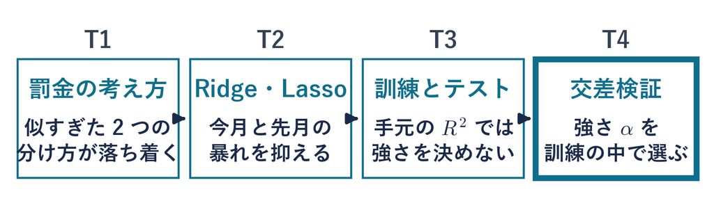

似すぎた変数を両方入れると係数が暴れ、罰金を掛けると分け方が落ち着く  
罰金の強さ $\alpha$ は、学ばせていないデータへの当たりで選ぶ

係数は訓練で求める／設定 $\alpha$ は CV の誤差で選ぶ／最後にテストで 1 回だけ採点

今回は列をずらして作った（今月〜12 か月前）。列の作り方はほかにもある。それはあとで